# Statistical inference with the GSS data

### Perception of lack of motivation

The final question concerned poor economic outcomes due to Blacks’ lack of motivation, racdif4/rd4.

#### Hypothesis test: Is the observed difference explained by chance?

To check the success-failure condition of a hypothesis test, we use the pooled proportion, and the values found in our exploratory data analysis section above.

```r
phat_rd4 <- (10042 + 1173) / (18148+2899)
phat_rd4_w <- phat_rd4 * 18148
phat_rd4_wn <- (1-phat_rd4) * 18148
phat_rd4_b <- phat_rd4 * 6363
phat_rd4_bn <- (1-phat_rd4) * 6363
cat ("Pooled proportion: ", round(phat_rd4, 4)," Success failure test of all groups (must be > 10): ", round(phat_rd4_w, 4),
     " ",round(phat_rd4_wn, 4), " ", round(phat_rd4_b, 4), " ", round(phat_rd4_b, 4), " ", round(phat_rd4_bn, 4))
```

```
## Pooled proportion:  0.5329  Success failure test of all groups (must be > 10):  9670.253   8477.747   3390.557   3390.557   2972.443
```

We meet the conditions for the sampling distribution of $\hat{p}_1 - \hat{p}_2$ to be normal:

- The sample is independently drawn (random sampling without replacement).
- The sample is less than 10% of the population.
- We have 10 or more successes and failures in each group.

```
## Response variable: categorical (2 levels, success: Yes)
## Explanatory variable: categorical (2 levels)
## n_Black = 2899, p_hat_Black = 0.4046
## n_White = 18148, p_hat_White = 0.5533
## H0: p_Black =  p_White
## HA: p_Black != p_White
## z = -14.903
## p_value = < 0.0001
```

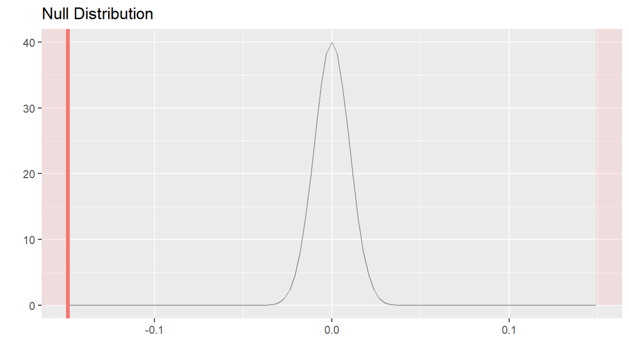

```r
inference(y = racdif4, x = race, data = sra, statistic = "proportion", type = "ht", success='Yes', order=c("Yes", "No"),
          method = "theoretical", alternative='twosided', null=0, show_eda_plot=FALSE)
```

Our p_value is .0001. Because this is less than .05, we reject the null hypothesis. The difference in proportions is not explained by chance.

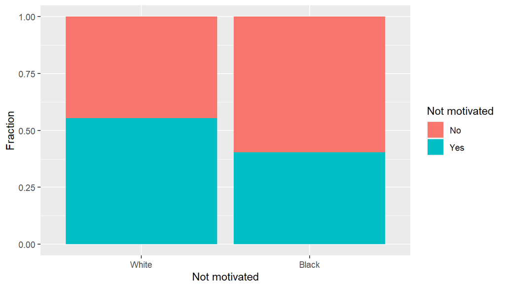

```r
p4 <- ggplot(data = sra, aes(fill=factor(racdif4, levels=c("No", "Yes")), x=race )) +
  geom_bar(position='fill', stat='count') +
  xlab(label="Not motivated") + ylab(label="Fraction")
p4 + labs(fill ="Not motivated")
```

```r
inference(y = racdif4, x = race, data = sra, statistic = "proportion", type = "ci", success='Yes', order=c("Yes", "No"),
           method = "theoretical", show_eda_plot = FALSE )
```

```
## Response variable: categorical (2 levels, success: Yes)
## Explanatory variable: categorical (2 levels)
## n_Black = 2899, p_hat_Black = 0.4046
## n_White = 18148, p_hat_White = 0.5533
## 95% CI (Black - White): (-0.168 , -0.1294)
```

Here, Whites are more likely than Blacks to identify Blacks’ lack of motivation as a cause of poorer economic outcomes. We are 95% confident that the *difference* between Blacks and Whites is 14.87% +/- 1.93% (12.94%, 16.8%).

For both of our tests of classic racism, our confidence intervals do not include the possibility that Black - White = 0, so we reject the null hypothesis regarding classic racism and find support for the alternative hypothesis: Whites are more racist than Blacks.